# HW2

Anish Mohan

January 25, 2017

## 2. Reviewing Data

Source Data:- A. Tsanas, A. Xifara: ‘Accurate quantitative estimation of energy performance of residential buildings using statistical machine learning tools’, Energy and Buildings, Vol. 49, pp. 560-567, 2012

```r
library(ggplot2)
  # Read the dataset
  energy = read.csv("EnergyEfficiencyData.csv", header = TRUE, stringsAsFactors = FALSE)
```

```r
  # Review the names of the columns or the features
  names(energy)
```

```
##  [1] "Relative.Compactness"      "Surface.Area"
##  [3] "Wall.Area"                 "Roof.Area"
##  [5] "Overall.Height"            "Orientation"
##  [7] "Glazing.Area"              "Glazing.Area.Distribution"
##  [9] "Heating.Load"              "Cooling.Load"
```

```r
  # Print a summary of the datatypes in the data.
  str(energy)
```

```
## 'data.frame':    768 obs. of  10 variables:
##  $ Relative.Compactness     : num  0.98 0.98 0.98 0.98 0.9 0.9 0.9 0.9 0.86 0.86 ...
##  $ Surface.Area             : num  514 514 514 514 564 ...
##  $ Wall.Area                : num  294 294 294 294 318 ...
##  $ Roof.Area                : num  110 110 110 110 122 ...
##  $ Overall.Height           : num  7 7 7 7 7 7 7 7 7 7 ...
##  $ Orientation              : int  2 3 4 5 2 3 4 5 2 3 ...
##  $ Glazing.Area             : num  0 0 0 0 0 0 0 0 0 0 ...
##  $ Glazing.Area.Distribution: int  0 0 0 0 0 0 0 0 0 0 ...
##  $ Heating.Load             : num  15.6 15.6 15.6 15.6 20.8 ...
##  $ Cooling.Load             : num  21.3 21.3 21.3 21.3 28.3 ...
```

The data here shows that there are 768 rows (sample) and 10 columns (features).

```r
  # Quick check to see if there are any NA's in the data
  summary(is.na(energy))
```

```
##  Relative.Compactness Surface.Area    Wall.Area       Roof.Area
##  Mode :logical        Mode :logical   Mode :logical   Mode :logical
##  FALSE:768            FALSE:768       FALSE:768       FALSE:768
##  NA's :0              NA's :0         NA's :0         NA's :0
##  Overall.Height  Orientation     Glazing.Area    Glazing.Area.Distribution
##  Mode :logical   Mode :logical   Mode :logical   Mode :logical
##  FALSE:768       FALSE:768       FALSE:768       FALSE:768
##  NA's :0         NA's :0         NA's :0         NA's :0
##  Heating.Load    Cooling.Load
##  Mode :logical   Mode :logical
##  FALSE:768       FALSE:768
##  NA's :0         NA's :0
```

Per this chart, none of the columns have any NAs.

###. Exploratory Data Analysis

1. Heating and Cooling Load as a function of Surface Area

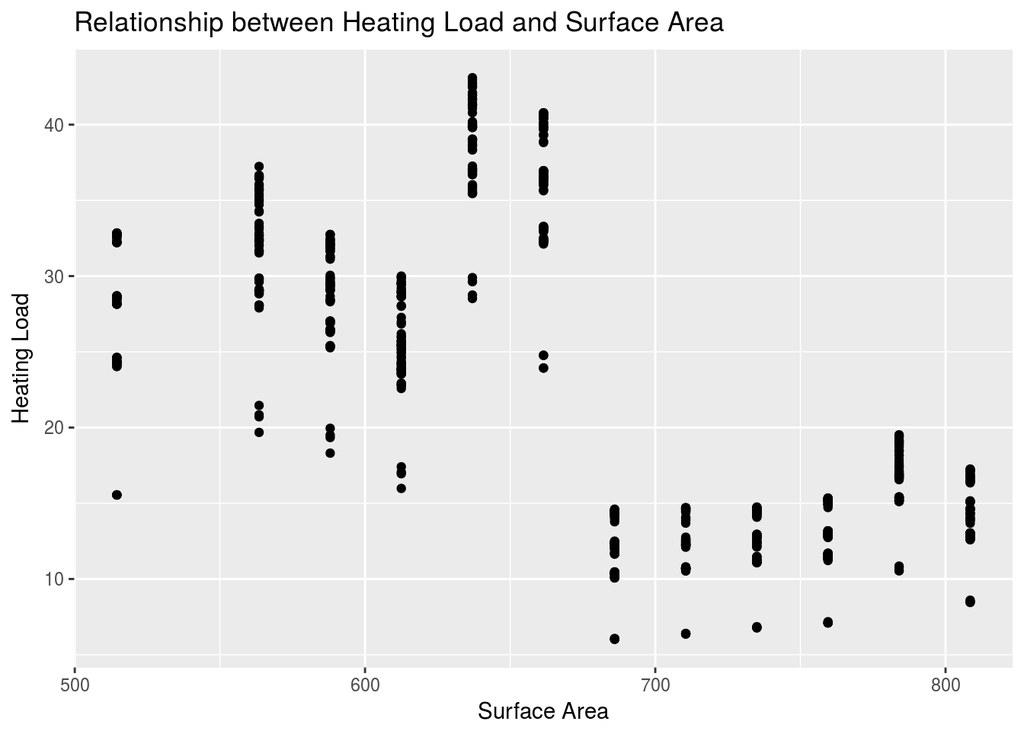

```r
      #Scatter plot of the Heating/Cooling Load and Surface Area
      ggplot(energy, aes(y = Heating.Load, x = Surface.Area))+ geom_point() + xlab("Surface Area") + ylab("Heating Load") + ggtitle("Relationship between Heating Load and Surface Area")
```

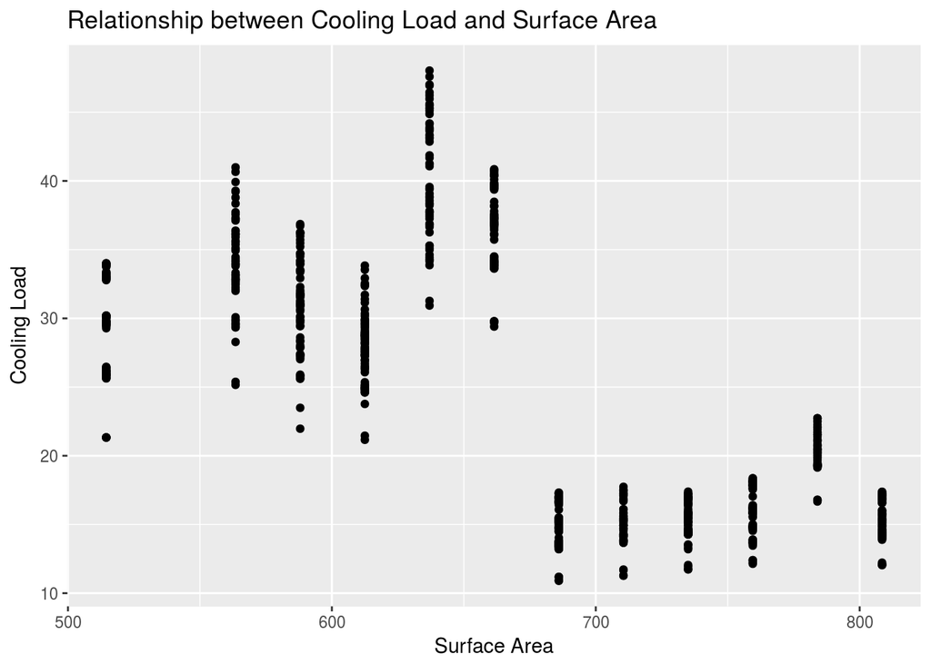

```
  + This scatter plot shows that that Heating/Cooling load is higher when the Surface areas is <675 units. As the Surface area increases beyond 675 units, the heating and cooling load starts decreasing

  + Next we will analyze if Surface Area in conjunction with other parameters impacts heating and cooling load
```

```r
      ggplot(energy, aes(y = Cooling.Load, x = Surface.Area))+ geom_point() + xlab("Surface Area") + ylab("Cooling Load") + ggtitle("Relationship between Cooling Load and Surface Area")
```

2. Heating and Cooling Load as a function of Roof area along with impact of other variables

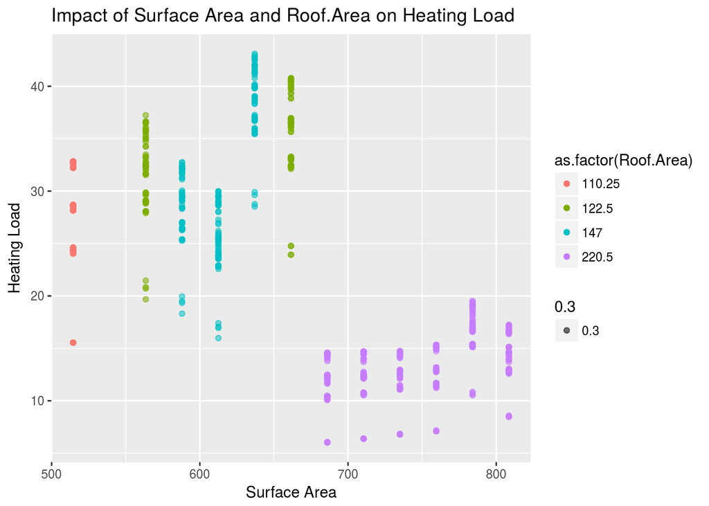

```r
      #Scatter Plot of Heating and Cooling Load and Surface Area with Orientation as a factor
      ggplot(energy, aes(y = Heating.Load, x = Surface.Area)) + geom_point(aes(color = as.factor(Roof.Area), alpha = 0.3)) + xlab("Surface Area") + ylab("Heating Load") + ggtitle("Impact of Surface Area and Roof.Area on Heating Load")
```

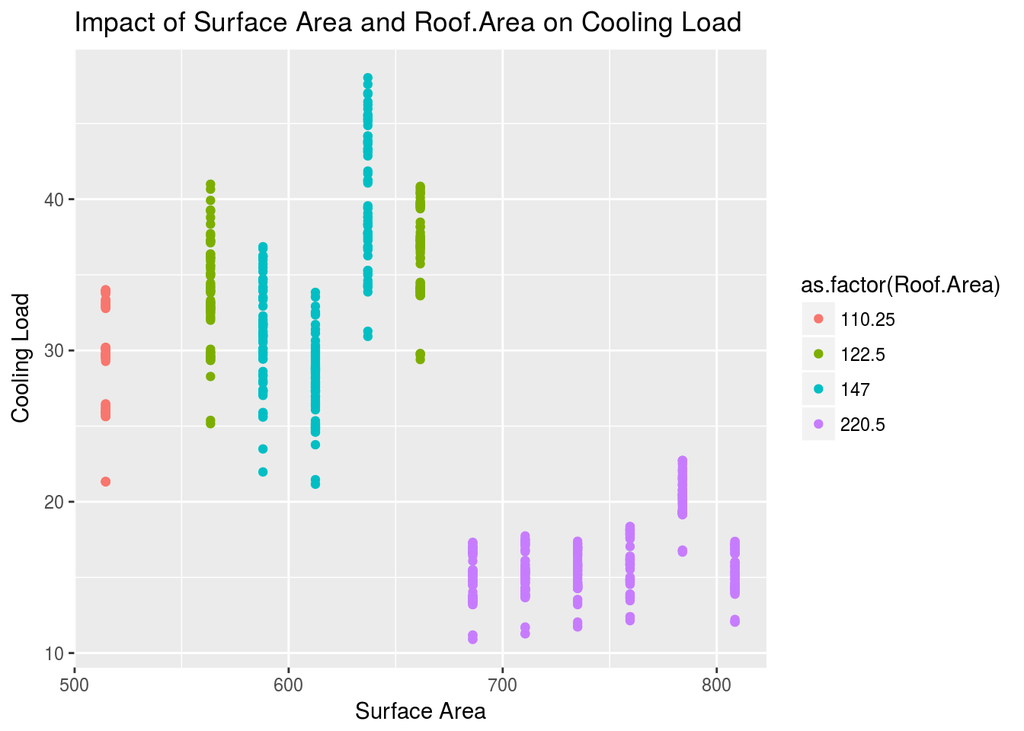

```
+ In this plot it is shown that if Surface Area is larger than ~675 units, the Roof area is large. For such building, the Heating and the cooling load is lower than building that have small Surface area and Roof Area.
```

```r
      ggplot(energy, aes(y = Cooling.Load, x = Surface.Area)) + geom_point(aes(color = as.factor(Roof.Area))) + xlab("Surface Area") + ylab("Cooling Load") + ggtitle("Impact of Surface Area and Roof.Area on Cooling Load")
```

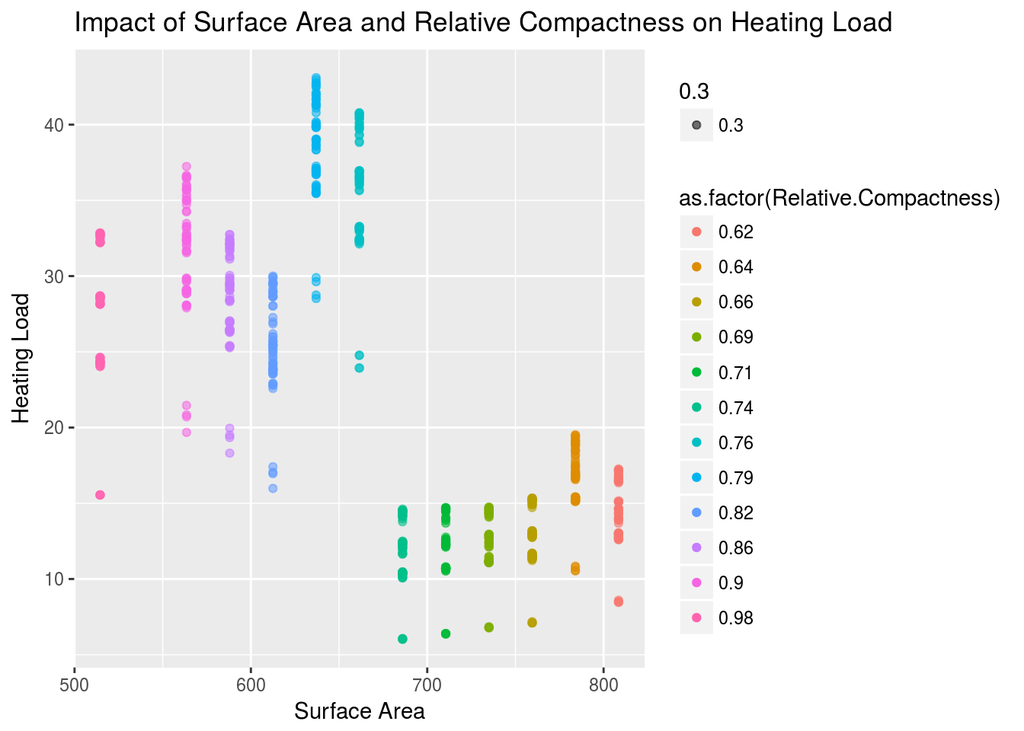

```r
      ggplot(energy, aes(y = Heating.Load, x = Surface.Area)) + geom_point(aes(color = as.factor(Relative.Compactness), alpha = 0.3)) + xlab("Surface Area") + ylab("Heating Load") + ggtitle("Impact of Surface Area and Relative Compactness on Heating Load ")
```

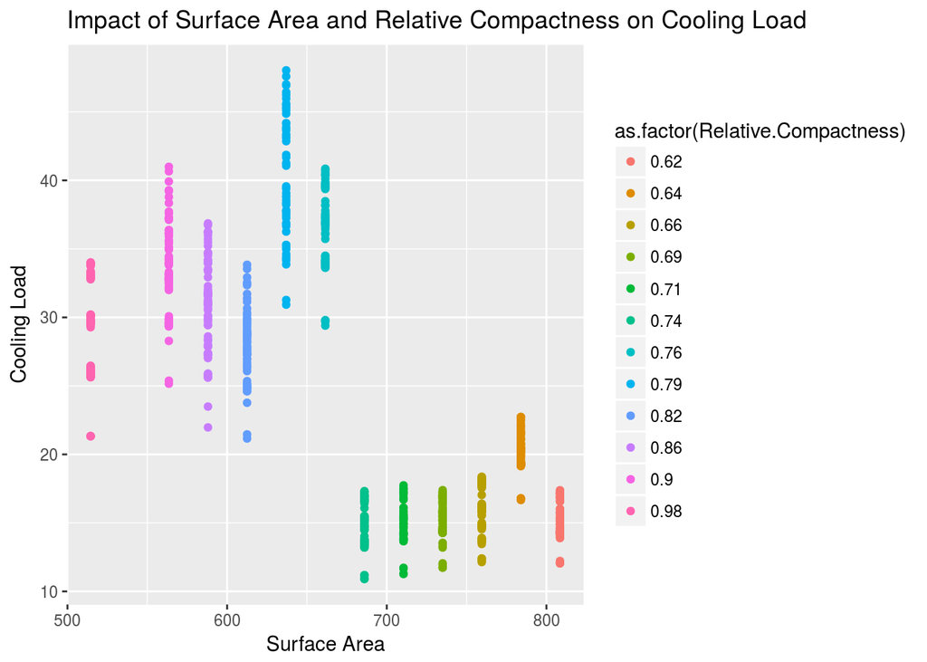

```r
      ggplot(energy, aes(y = Cooling.Load, x = Surface.Area)) + geom_point(aes(color = as.factor(Relative.Compactness))) + xlab("Surface Area") + ylab("Cooling Load") + ggtitle("Impact of Surface Area and Relative Compactness on Cooling Load ")
```

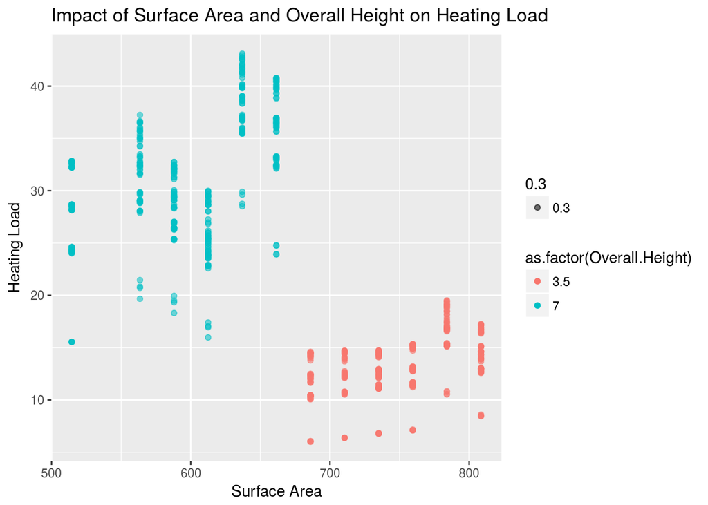

  ```r
    ggplot(energy, aes(y = Heating.Load, x = Surface.Area)) + geom_point(aes(color = as.factor(Overall.Height), alpha = 0.3)) + xlab("Surface Area") + ylab("Heating Load") + ggtitle("Impact of Surface Area and Overall Height on Heating Load ")
  ```

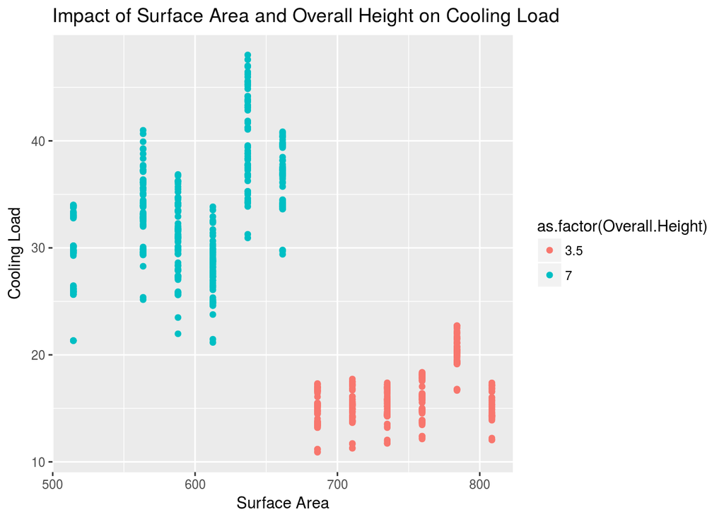

  ```r
    ggplot(energy, aes(y = Cooling.Load, x = Surface.Area)) + geom_point(aes(color = as.factor(Overall.Height))) + xlab("Surface Area") + ylab("Cooling Load") + ggtitle("Impact of Surface Area and Overall Height on Cooling Load ")
  ```

  - In this plot is is shows that if Surface Area is larger than ~675 units, then the Overall Height is ~3.5units and the heating and Cooling loads are lower.

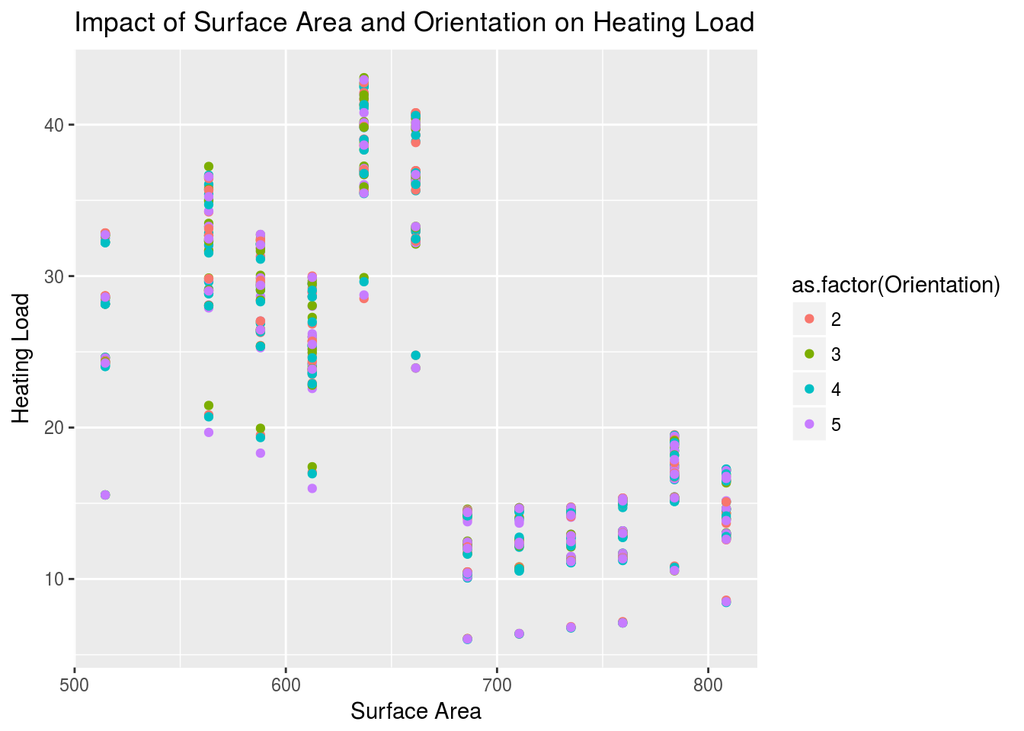

  ```r
    ggplot(energy, aes(y = Heating.Load, x = Surface.Area)) + geom_point(aes(color = as.factor(Orientation))) + xlab("Surface Area") + ylab("Heating Load") + ggtitle("Impact of Surface Area and Orientation on Heating Load ")
  ```

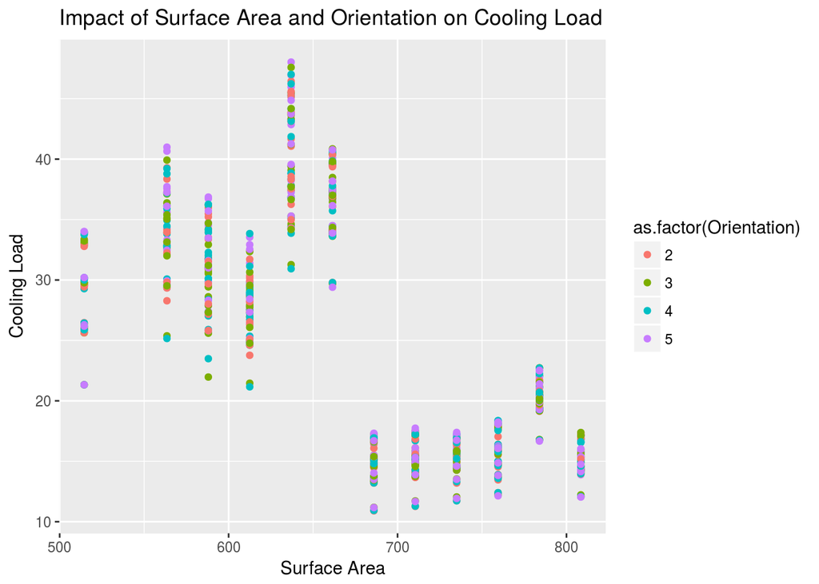

  ```r
    ggplot(energy, aes(y = Cooling.Load, x = Surface.Area)) + geom_point(aes(color = as.factor(Orientation))) + xlab("Surface Area") + ylab("Cooling Load") + ggtitle("Impact of Surface Area and Orientation on Cooling Load ")
  ```

  - This plot shows that there are no preferred orientation along with Surface Area such that it leads to lower heating or cooling load.